# Activity Monitor

```r
library(dplyr)
library(data.table)
```

### Download the data from the source URL

```r
if (!file.exists("../Data/activity.zip")) {
    url <- "https://d396qusza40orc.cloudfront.net/repdata%2Fdata%2Factivity.zip"
    zfile="../Data/activity.zip"
    download.file(url, zfile)
    unzip(zipfile=zfile, exdir="../Data")
}
```

### Load data from the downloaded file, add id column with sequential unique value

```r
df <- read.csv("../Data/Activity.csv")
df <- mutate(df, id = rownames(df))
```

### Ignore Missing Values

```r
noNA <- na.omit(df)
```

### 1. What is the total number of steps taken per day?

```r
noNA <- data.table(noNA, key="date")
dailySteps <- noNA [,sum(steps), by=key(noNA)]
setnames(dailySteps, "V1", "steps")
head(dailySteps)
```

```
##          date steps
## 1: 2012-10-02   126
## 2: 2012-10-03 11352
## 3: 2012-10-04 12116
## 4: 2012-10-05 13294
## 5: 2012-10-06 15420
## 6: 2012-10-07 11015
```

### Histogram of the total number of steps taken per day

(excluded missing values)

```r
cuts <- cut(dailySteps$steps,  c(0,5000, 10000, 15000, 20000, 25000),
           labels=c("5000",  "10000",  "15000", "20000", "25000"))
summary(cuts)
```

```
##  5000 10000 15000 20000 25000
##     5    12    28     6     2
```

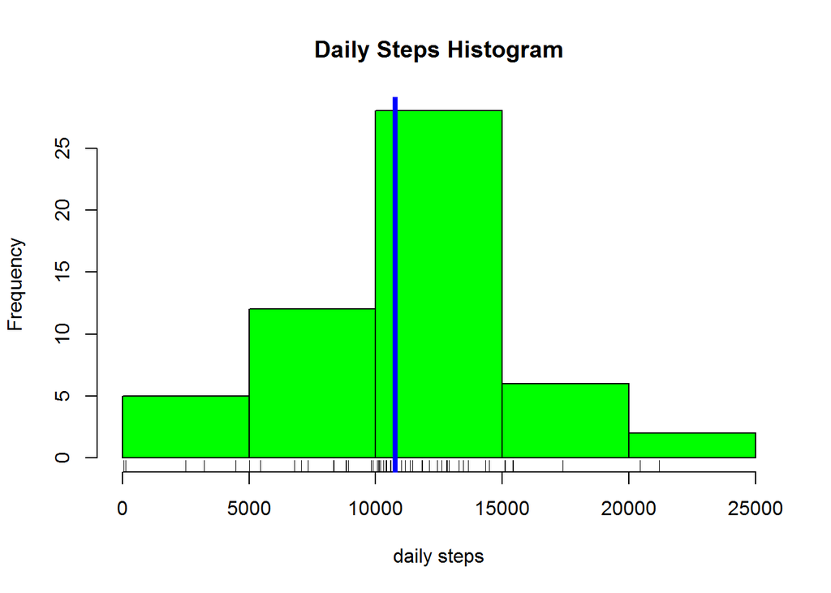

```r
hist(dailySteps$steps, col="green",
      main="Daily Steps Histogram", xlab="daily steps")
rug(dailySteps$steps)
abline(v=median(dailySteps$steps), lwd=4, col="blue")
```

```r
summary(dailySteps)
```

```
##          date        steps
##  2012-10-02: 1   Min.   :   41
##  2012-10-03: 1   1st Qu.: 8841
##  2012-10-04: 1   Median :10765
##  2012-10-05: 1   Mean   :10766
##  2012-10-06: 1   3rd Qu.:13294
##  2012-10-07: 1   Max.   :21194
##  (Other)   :47
```

### 2. The Average Daily Activity pattern

- Make a time series plot (type=“1”)
- X-Axis is 5-minute intervals, and y-axis the averaged across all days

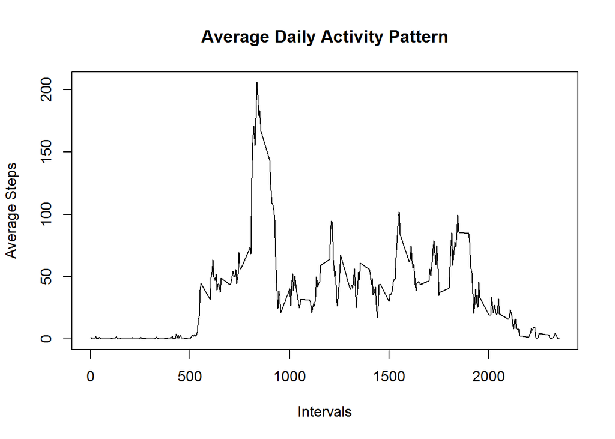

```r
vy <- tapply(noNA$steps, noNA$interval, mean)
vx <- as.integer(names(vy))
plot(vx, vy, type="l", xlab="Intervals",
     ylab="Average Steps",
     main="Average Daily Activity Pattern")
```

- The 5-minute interval that has the maximum number of steps

```r
z <- as.data.frame(vy)
vy[which(z$vy == max(z$vy))]
```

```
##      835
## 206.1698
```

### 3. Imputing missing values

The presense of missing days may introduce bias into some calculations or summaries of data.

#### The toal number of missing values in the dataset. (rows with NA)

```r
nrow(subset(df, is.na(steps) ==TRUE))
```

```
## [1] 2304
```

### Fill missing data with imputed mean values

```r
library(Hmisc)
df.i <- with(df, impute(steps, mean))
df$impmean <- as.integer(df.i)
```

```r
dt <- data.table(df, key="date")
ds <- dt[,sum(impmean), by=key(dt)]
setnames(ds, "V1", "impmean")
```

- Make a historam of the total number of steps taken each day

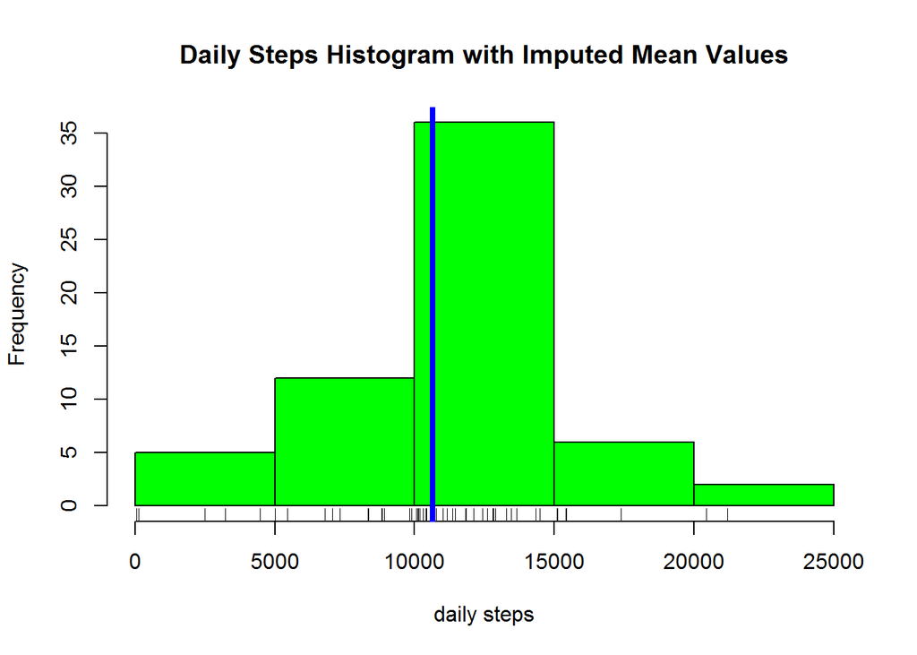

```r
hist(ds$impmean, col="green",
     main="Daily Steps Histogram with Imputed Mean Values", xlab="daily steps")
rug(ds$impmean)
abline(v=median(ds$impmean), lwd=4, col="blue")
```

Do Mean and Median values differ from the estimates from the first part of assignment? Yes, there is a little difference.

```r
summary(ds)
```

```
##          date       impmean
##  2012-10-01: 1   Min.   :   41
##  2012-10-02: 1   1st Qu.: 9819
##  2012-10-03: 1   Median :10656
##  2012-10-04: 1   Mean   :10752
##  2012-10-05: 1   3rd Qu.:12811
##  2012-10-06: 1   Max.   :21194
##  (Other)   :55
```

- It appears there is little impact of imputing missing data on the estimates of the total daily number of steps?

### 4. Are there differences in activity patterns between weekdays and weekends?

Reshape dataset

```r
dt[,"asDate"] <- as.Date(dt[,date])
dt[,"wday"] <- weekdays(dt$asDate)
```